# TWO-WAY ANOVA

Thuy Tran

2023-09-23

### Theory

#### Two-Way ANOVA Table

Below is the ANOVA table for the two-way ANOVA analysis:

| Source of Variation | Degrees of Freedom (df) | Sum of Squares (SS) | Mean Square (MS) | F-Statistic (F) |
| --- | --- | --- | --- | --- |
| First Factor (Factor 1) | DFA | SSA | MSA = SSA / DFA | F1 |
| Second Factor (Factor 2) | DFB | SSB | MSB = SSB / DFB | F2 |
| Residuals | DFE | SSE | MSE = SSE / DFE |  |
| Total | DFT | SST |  |  |

- DFA: Degrees of Freedom for Factor 1
- DFB: Degrees of Freedom for Factor 2
- DFE: Degrees of Freedom for Residuals
- DFT: Total Degrees of Freedom
- SSA: Sum of Squares for Factor 1
- SSB: Sum of Squares for Factor 2
- SSE: Residual Sum of Squares
- SST: Total Sum of Squares
- MSA: Mean Square for Factor 1 (MSA = SSA / DFA)
- MSB: Mean Square for Factor 2 (MSB = SSB / DFB)
- MSE: Mean Square for Residuals (MSE = SSE / DFE)
- F1: F-Statistic for Factor 1 (F1 = MSA / MSE)
- F2: F-Statistic for Factor 2 (F2 = MSB / MSE)

### Problem 1: moisture of soil (without replication) - complete randomised design

#### The dataset

The moisture of the soil at different locations with different irrigation practice (A, B, C) (alpha=0.05). The dataset is as following:

```r
#Create the dataframe

A <- c(7.6, 9.3, 11.8, 12.4, 13.5, 12.9, 7.1, 10.8, 10.3, 9.4)
B <- c(9.1, 5.8, 5.9, 9.8, 9.3, 11.9, 3.6, 7.9, 8, 8.4)
C <- c(8.2, 10.1, 10.2, 12.6, 12.6, 13.1, 8.9, 7.8, 11.8, 8.6)
location <- c(1:10)
method <- c("A", "B", "C")
df <- data.frame(
  location = rep(location, times=length(method)),
  method = rep(method, each=c(length(A), length(B), length(C))),
  values = c(A, B, C)
)
# Convert 'Method' and 'Location' to factors
df$location <- as.factor(df$location)
df$method <- as.factor(df$method)
head(df)
```

```
##   location method values
## 1        1      A    7.6
## 2        2      A    9.3
## 3        3      A   11.8
## 4        4      A   12.4
## 5        5      A   13.5
## 6        6      A   12.9
```

```r
#View(df)
```

#### Perform ANOVA - 1

**Hypotheses**

H0: There are no significant differences in soil moisture levels among the different irrigation practices (A, B, C) at the various locations.

H1: There is a significant difference in soil moisture levels among the different irrigation practices (A, B, C) at the various locations.

We do not consider the relationship between the irrigation practices and the locations.

```r
anova.1 <- aov(values ~ location + method, data=df)
summary(anova.1)
```

```
##             Df Sum Sq Mean Sq F value   Pr(>F)
## location     9  96.23  10.692   5.858 0.000733 ***
## method       2  41.07  20.537  11.253 0.000676 ***
## Residuals   18  32.85   1.825
## ---
## Signif. codes:  0 '***' 0.001 '**' 0.01 '*' 0.05 '.' 0.1 ' ' 1
```

**Conclusion** p-value of method < 0.05, therefore, therefore reject H0.

#### Check for ANOVA assumption

##### Normality

###### Botlox instead of QQ-plot

(only preference, I do not draw 3 histograms)

If the data is not normal distributed => use Friedman test instead.

**Draw botplot (fast)**

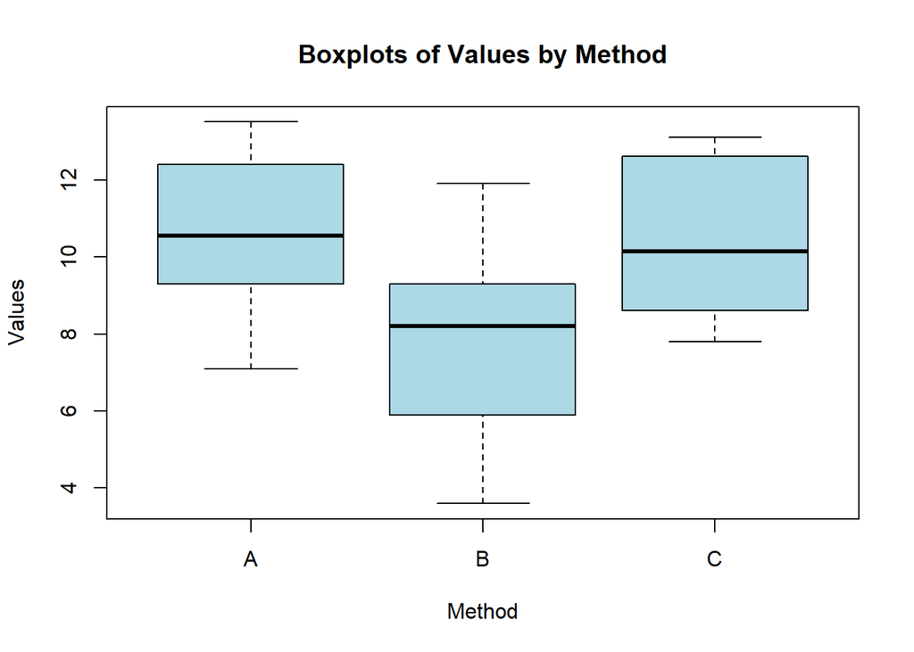

```r
boxplot(values ~ method, data = df,
        xlab = "Method", ylab = "Values",
        main = "Boxplots of Values by Method", col = "lightblue")
```

**Comment:**

The A, B, C do not look really much distributed, because the median lines are not really in the middle. We continue on using testing.

###### Shapiro-Wilk test

**Hypotheses**

H0: The data follows a normal distribution.

H1: The data does not follow a normal distribution.

```r
ano.residuals <- residuals(object=anova.1)
#Shapiro test

shapiro.test(x=ano.residuals)
```

```
##
##  Shapiro-Wilk normality test
##
## data:  ano.residuals
## W = 0.97611, p-value = 0.7154
```

**Conclusion:** the p-value > 0.05 => accept H0, the data is normaly distributed.

##### Check for homoscedasticity

###### Use Lavene’s test

**Hypotheses**

*For locations:*  
H0: The variances of the locations are equal (homoscedasticity).  
H1: The variances of the locations are not equal (heteroscedasticity).

*For irrigating practices:*

H0: The variances of the irrigating practices are equal (homoscedasticity).  
H1: The variances of the irrigating practices are not equal (heteroscedasticity).

```r
library(car)
lv1.1 <- leveneTest(df$values, df$location)
print(lv1.1)
```

```
## Levene's Test for Homogeneity of Variance (center = median)
##       Df F value Pr(>F)
## group  9  0.4627 0.8825
##       20
```

```r
lv2.1 <- leveneTest(df$values, df$method)
print(lv2.1)
```

```
## Levene's Test for Homogeneity of Variance (center = median)
##       Df F value Pr(>F)
## group  2  0.0167 0.9835
##       27
```

### Problem 2: Wheat yield (without replication) - Latin squared design

To examine the affects of different types of fertilizer on wheat yield, and the affect of the soil quality, therefore, the experiment followed latin squared design (consider the affect of rows and columns), and we do not consider the relationship between the types of fertilizer and locations.

```r
library(readxl)
df1 <- read_excel("Wheat.xlsx")
df1$Treat <- as.factor(df1$Treat)
df1$Row <- as.factor(df1$Row)
df1$Col <- as.factor(df1$Col)
head(df1)
```

```
## # A tibble: 6 × 5
##     No. Yield Treat Row   Col
##   <dbl> <dbl> <fct> <fct> <fct>
## 1     1  72.2 E     1     1
## 2     2  36.4 A     2     1
## 3     3  71.5 C     3     1
## 4     4  68.9 B     4     1
## 5     5  82   D     5     1
## 6     6  55.4 C     1     2
```

**Hypotheses:** Note: each square is a treatment

H0: all treatment means (squares) are equal.  
H1: all treatment means (squares) are not equal.

```r
anova.2 <- aov(Yield ~ Treat + Row + Col, data=df1)
summary(anova.2)
```

```
##             Df Sum Sq Mean Sq F value   Pr(>F)
## Treat        4 1284.5   321.1   19.07  3.9e-05 ***
## Row          4 2326.4   581.6   34.54  1.7e-06 ***
## Col          4  901.4   225.3   13.38 0.000222 ***
## Residuals   12  202.1    16.8
## ---
## Signif. codes:  0 '***' 0.001 '**' 0.01 '*' 0.05 '.' 0.1 ' ' 1
```

Conclusion: p-value < 0.05 => reject H0.

### Problem 2: Bird diets (with replication)

12 birds (6 males and 6 females) are fed with 2 different type of diets (1, 2). Each diet is used for 3 female birds and 3 male birds. The value is the grams in 1 months, detail is in the following dataset.

```r
df2 <- read_excel("bird_diets.xlsx")
df2$Gender <- as.factor(df2$Gender)
df2$Diet<- as.factor(df2$Diet)
head(df2)
```

```
## # A tibble: 6 × 3
##   Gender Diet  Value
##   <fct>  <fct> <dbl>
## 1 Male   d1     70.9
## 2 Male   d1     67.9
## 3 Male   d1     69.9
## 4 Male   d2     59.2
## 5 Male   d2     53.8
## 6 Male   d2     47
```

**Hypotheses**

Level of significance is 0.05

*Null Hypotheses (H0):*  
H0_gender: There is no significant difference in the mean amount of food eaten by male and female birds.  
H0_diet: There is no significant difference in the mean amount of food eaten by birds fed with diet 1 and diet 2.  
H0_interaction: The effect of diet on the amount of food eaten is the same for both male and female birds.

*Alternative Hypotheses (H1):*  
H1_gender: There is a significant difference in the mean amount of food eaten between male and female birds.  
H1_diet: There is a significant difference in the mean amount of food eaten by birds fed with diet 1 and diet 2.  
H1_interaction: The effect of diet on the amount of food eaten is different for male and female birds.

**Perform ANOVA**

```r
anova.3 <- aov(Value ~ Gender * Diet, data=df2)
summary(anova.3)
```

```
##             Df Sum Sq Mean Sq F value   Pr(>F)
## Gender       1   48.4    48.4   3.309 0.106384
## Diet         1  670.5   670.5  45.847 0.000142 ***
## Gender:Diet  1    4.9     4.9   0.338 0.577086
## Residuals    8  117.0    14.6
## ---
## Signif. codes:  0 '***' 0.001 '**' 0.01 '*' 0.05 '.' 0.1 ' ' 1
```

**Conclusion:** Based on p-values, only the H0 of Diet being rejected (the p-value of Diet < 0.05).  
Diets affect the the amount of food eaten by the birds.  
Gender does not affect the amount of food eaten by the birds.  
No interaction between the diets and the genders in terms of amount of food consumption.

##### Check for homoscedasticity

###### Use Lavene’s test

**Hypotheses**

*For diet:*  
H0: The variances of the diet are equal (homoscedasticity).  
H1: The variances of the diet are not equal (heteroscedasticity).

*For gender:*

H0: The variances of the gender are equal (homoscedasticity).  
H1: The variances of the gender are not equal (heteroscedasticity).

*For interaction:*

H0: The variances of the interaction are equal (homoscedasticity).  
H1: The variances of the interaction are not equal (heteroscedasticity).

```r
homogeneity.groups <- leveneTest(anova.3)
print("Interaction")
```

```
## [1] "Interaction"
```

```r
print(homogeneity.groups)
```

```
## Levene's Test for Homogeneity of Variance (center = median)
##       Df F value Pr(>F)
## group  3  1.5593 0.2732
##        8
```

```r
lv2.1 <- leveneTest(df2$Value, df2$Gender)
print("Gender")
```

```
## [1] "Gender"
```

```r
print(lv2.1 )
```

```
## Levene's Test for Homogeneity of Variance (center = median)
##       Df F value Pr(>F)
## group  1  0.2805 0.6079
##       10
```

```r
lv2.2 <- leveneTest(df2$Value, df2$Diet)
print("Diet")
```

```
## [1] "Diet"
```

```r
print(lv2.2)
```

```
## Levene's Test for Homogeneity of Variance (center = median)
##       Df F value Pr(>F)
## group  1   1e-04  0.993
##       10
```

**Comment:** The p-values of all tests > 0.05 => accept H0, in other words the homogeneity is met.

##### Normality

###### QQ-plot

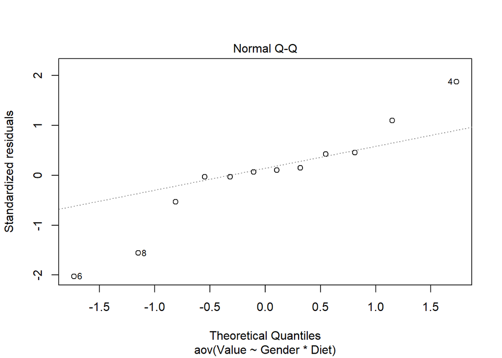

```r
plot(anova.3,2)
```

###### Shapiro-Wilk test

**Hypotheses**

H0: The data follows a normal distribution.

H1: The data does not follow a normal distribution.

```r
ano.residuals <- residuals(object=anova.3)
shapiro.test(x=ano.residuals)
```

```
##
##  Shapiro-Wilk normality test
##
## data:  ano.residuals
## W = 0.93341, p-value = 0.4176
```

**Comment:** The p-value > 0.05 => accept H0, in other words, the data follows a normal distribution.

###### The resudials vs fitted plot

Ideally, in a well-fitted regression model, we want to see a random scatter of points with no clear pattern. This suggests that the model has captured the underlying relationship between the independent and dependent variables adequately.  
The common patterns:  
1. Random Scatter: A random scatter of points with no clear pattern suggests a well-fitted model and adherence to linear regression assumptions.  
2. U-Shaped or Funnel Shape: Residuals forming a U-shaped or funnel shape indicate heteroscedasticity, where the variance of residuals varies across the range of the independent variable(s).  
3. Curved Pattern: A curved pattern suggests a non-linear relationship between variables, potentially requiring polynomial terms or a different regression model.  
4. Outliers or Clusters: Outliers or clusters of points away from the main cluster may be influential data points that impact model fit, requiring further investigation.

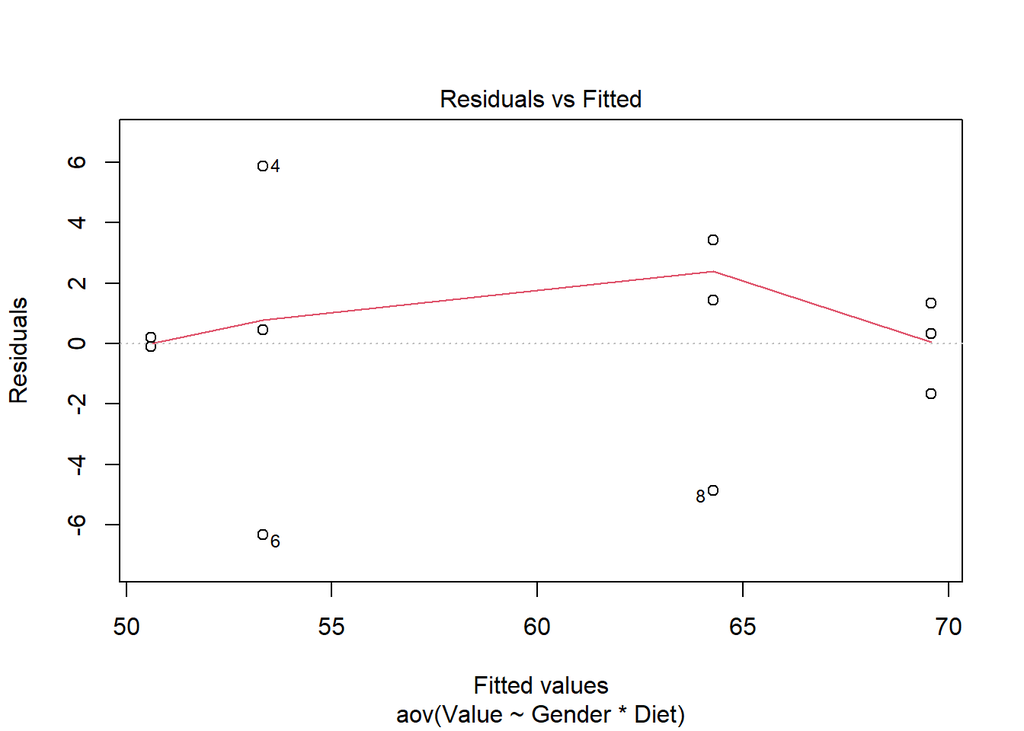

```r
plot(anova.3,1)
```